# YearUp Labor Project: Predicting Counterfactual Wages for YU Participants

April 2021

# Loading required packages

```r
# Ensure that pacman is installed for package management and loading.
if (!require("pacman")) install.packages("pacman")
pacman::p_load(tidyverse) # for data reading wrangling and visualization
```

```r
# for enabling dataframe manipulation
pacman::p_load(dplyr)
# for modeling, transforming, and visualizing data
pacman::p_load(tidyverse)
# for simplifying the process of creating tidy dat
pacman::p_load(tidyr)
# for working with tabular data
pacman::p_load(data.table)
# for data visualization
pacman::p_load(ggplot2)
# provides support to ggplot2 for labeling graphs
pacman::p_load(directlabels)
# for streamlining the model training process
pacman::p_load(caret)
# for fitting a generalized linear model
pacman::p_load(glmnet)
# for enabling fast implementation of random forests
pacman::p_load(ranger)
# for providing a general-purpose tool for dynamic report generation
pacman::p_load(knitr)
# for providing a prettier RMarkdown (1.0.1)
pacman::p_load(kableExtra)
# for forest-based statistical estimation and inference
pacman::p_load(grf)
```

# Brief Tutorial Description

The goal of this tutorial is to predict what the year over year wage changes of Year Up participants would have been, had they not participated in the program. We do this using the prediction model we built from a general population in the previous tutorial, and predict wage changes in the Year Up sample, based on their observable characteristics.

The tutorial goes through the following steps:

1. We load, clean and preprocess the Year-Up data. This includes making sure all the variables have the same names and are coded the same as in the CPS. It is important that the variables in the YearUp data are congruent with the CPS data, because we want to predict counterfactual wages in the Year-Up data from the model built in the CPS.
2. Using the best wage prediction model from the previous tutorial, we predict wage changes for Year-Up participants and thereby build our “control group”.
3. We compare the difference in mean actual outcomes with mean counterfactual predicted outcomes, by building a “treatment effect model”. This gives us the treatment effect, i.e. the return to participating in Year Up on wage changes.
4. Next, we repeat the above exercise for subgroups, and look e.g. at how returns to Year Up differ for men and women.

# Loading and Processing the Data

We begin by reading in the Year Up data. It comes in two separate files: the records on participants before they started Year Up are in a different dataset from than the post Year Up records. We need to load both and merge them on the “PACE_ID” - which is the unique person identifier. As previously in the case of CPS data, we further “enrich” this data with task and county data, that we merge to participants’ occupations and counties respectively, to have richer information on both. The task data stems from Autor and Dorn’s 2013 paper: “The Growth of Low-Skill Service Jobs and the Polarization of the US Labor Market” and described the routine, manual and abstract task intensity of occupations. More information about the data can be found [here](https://www.ddorn.net/data.htm). The additional location data comes from “Neighborhood Characteristics by County” in Opportunity Insight’s data library which can be found [here](https://opportunityinsights.org/data/).

Since our wage prediction model in the CPS uses these additional variables, we also need them in this dataset.

```r
# Load the pre- and post-YU data
df_post<-fread("Datasets/20210119_YU_post_data.csv") #post Year Up records on individuals
df_pre<-fread("Datasets/20210119_YU_pre_data.csv")   #pre Year Up records on individuals

# Load the CPI data
cpi <- read.csv("Datasets/cpi.csv") # yearly consumer price index with which we deflate earnings to USD 2010.

# Load onet crosswalk occupation classifications data
df_xwalk<-fread("Datasets/onet_occ2010_crosswalk.csv") #Year Up occupations have been classified (by our internal algorithm, not shown here - from plein text to onet occupations. Because of our CPS wage prediction model, we need occupations classified with the CPS occ2010 classificaiton. We therefore use a so-called classification crosswalk, which is tells us what the corresponing occ2010 code to each o-net code is.)

# Load occupation digit data
occ1digit<-fread("Datasets/occ1digit.csv")

# Load  task data
yu_tasks<-fread("Datasets/tasks_2010.csv")

# Load FIPS encoding data - to make sure we can merge the files as needed.
metro_fips<-fread("Datasets/fips_site_location.csv")

# Load CPS regions data
region<-fread("Datasets/state_to_region.csv")

# Load county-level data
county_vars<-fread("Datasets/count_level_covars.csv")
```

We first merge the pre- and post-YU data together by the person id (PACE_ID). Then, we add the CPI to the year records, in order to deflate wages and make them constant 2010 USD. Further, we add an occupational encoding crosswalk: Year Up occupations have been classified (by our internal NLP algorithm, not shown here) - from plein text to O NET occupations. Because of our CPS wage prediction model, we need occupations classified with the CPS occ2010 classificaiton. We therefore use a so-called classification crosswalk, which tells us what the corresponing occ2010 code to each O NET code is. We then add the relevant county-level variables to counties as well as task indices to occupations to the Year Up data.

```r
# Merge the pre- and post-YU data
yu_df<-merge(df_post,df_pre, by=c("PACE_ID", "Gender", "Race", "Age_at_Start_of_Cohort", "State", "Site", "Edu"), all.x = FALSE, all.y = FALSE)
yu_df<-yu_df %>% distinct(PACE_ID, .keep_all = TRUE) #there are a few duplicate pace_ids, which should not be the case - we drop them.

# Rename YU data to have the same names and encodings and CPS data.
yu_df<-yu_df %>%
  mutate(sex=Male_Flag,
         year_pre=Year-1,
         year_post=Year,
         age_pre=Age_at_Start_of_Cohort-1,
         age2_pre=age_pre^2,
         age_post=Age_at_Start_of_Cohort,
         age2_post=age_post^2,
         race_white= if_else(Race=="White",1,0),
         race_black= if_else(Race=="Black or African American",1,0),
         race_asian= if_else(Race=="Asian",1,0),
         edu_num= Edu,
         experience=Exp_4,
         experience2=experience^2)

# Unify naming for pre and post YU jobs and earnings
yu_df<-yu_df %>%
  mutate(occ_onet_pre=ONET_4_Job_preYU,
         earnings_pre=ONET_4_Salary_pre_YU,
         occ_onet_post=ONETCode_post_YU,
         earnings_post=SAL_YU_POSTYU)

# keep only variables of interest
yu_df <-yu_df%>%
  select(PACE_ID,Site,Cohort, sex, race_white,
         race_asian, race_black, edu_num, experience, experience2,
         year_pre, age_pre,age2_pre, occ_onet_pre,earnings_pre,
         year_post,age_post, age2_post,occ_onet_post,earnings_post)


# rehape data from wide to "long", so that we have two entries per individual, pre and post.
yu_df_long<-reshape(yu_df, direction='long',
                    varying=c("age_pre","age2_pre", "earnings_pre","occ_onet_pre","year_pre",
                               "age_post", "age2_post","earnings_post", "occ_onet_post", "year_post"),
                    timevar='prepost',
                    times=c('1_pre', '2_post'),
                    v.names=c('age', 'age2','earnings','occ_onet', 'year'),
                    idvar='PACE_ID')
```

## Applying log transformation on wages and creation of outcome variable: change in log earnings

We apply a log transformation on the pre and post real yearly earnings 1 and 2 (1 is pre and 2 is post), ‘real_yearly_earnings_1’ and ‘real_yearly_earnings_2’, such that the variable ‘log_d_earn’ is the log ratio of the ‘real_yearly_earnings_2’ to ‘real_yearly_earnings_1’ (i.e. log_d_earn = log(real_yearly_earnings_2/real_yearly_earnings_1)). This log transformation is appropriate because it deals with the positively skewed distribution of the yearly earnings variables. Also, note that while applying this log transformation, we add a delta of 0.001 to these real yearly earnings in order to prevent the log values from “exploding” and becoming NaNs in case the earnings have a value of 0.

```r
## Deflate wages (adjust for inflation) to USD 2010 real wages
# Merge cpi & convert to real values with 2010 base rate
yu_df_long <- left_join(yu_df_long,cpi, by="year", all.x = TRUE)

yu_df_long <- yu_df_long  %>%
  mutate(real_yearly_earnings=earnings/value)

# log transformation of real yearly earnings (in levels), plus inserting a small data in case some earnings are 0.

yu_df_long<-yu_df_long %>%
  mutate(real_yearly_earnings=if_else(real_yearly_earnings==0,0.001,real_yearly_earnings),
         log_earnings=log(real_yearly_earnings))

# Merge onet crosswalk to compare handle CPS occupation coding
yu_df_long<-merge(yu_df_long, df_xwalk, by.x ="occ_onet", by.y ="onet_soc_code", all.x = TRUE)

# Merge YU data with occupation coding data
yu_df_long<-merge(yu_df_long, occ1digit, by= "occ2010", all.x = TRUE)

# Merge YU data with tasks data
yu_df_long<- merge(yu_df_long,yu_tasks,by="occ2010",all.x = TRUE)

# Merge fips encoding
metro_fips<-metro_fips %>% select(-V4, county_fips)
yu_df_long<-merge(yu_df_long,metro_fips, by="Site", all.x = TRUE)

# Merge county level info
county_vars<-county_vars %>%
  select(cty, county_name, cty_pop2000, cz, cz_name, cz_pop2000, intersects_msa,
         cs00_seg_inc, cs00_seg_inc_pov25, cs00_seg_inc_aff75, cs_race_theil_2000,
         gini99, poor_share, inc_share_1perc, frac_middleclass,
         rel_tot, cs_frac_black, cs_frac_hisp, unemp_rate, pop_d_2000_1980,
         lf_d_2000_1980, cs_labforce, cs_elf_ind_man, cs_born_foreign, mig_inflow,
         mig_outflow, pop_density, frac_traveltime_lt15, hhinc00, median_house_value, cs_educ_ba,  cs_fam_wkidsinglemom, crime_total, subcty_exp_pc, taxrate, tax_st_diff_top20)
yu_df_long<-merge(yu_df_long,county_vars, by.x="fips", by.y = "cty", all.x = TRUE)

# Get regions from CPS
yu_df_long<-merge(yu_df_long, region, by.x ="state_fips", by.y ="statefip",all.x = TRUE)

# Get values of occ2010 to restrict to in training data
occuring<-paste(unique(yu_df_long$occ2010), collapse=",")

# Get the occupations of YU partipants before the training program
pre<-yu_df_long %>% filter(prepost=="1_pre")
startocc<-paste(unique(pre$occ2010), collapse=",") # In the first tutorial, this is the vector on which we restrict which occupations we keep in the CPS data - i.e. all occuring starting occupations pre-YU in this data.

# Get the occupations of YU partipants after the training program
post<-yu_df_long %>% filter(prepost=="2_post")
endocc<-paste(unique(post$occ2010), collapse=",")
```

```r
yu_df <- reshape(yu_df_long, direction='wide',
                idvar='PACE_ID',
                timevar= "prepost")

# Log earnings change
yu_df <- yu_df %>%
  mutate(log_d_earn=log_earnings.2_post - log_earnings.1_pre)

# Now that we have generated the earnings change variable, we can keep only one line per individual, the pre-records are enough. Before we do that, let's generate a copy of the datasets with two record per individual, in case we still need it.

yu_df_copy <- yu_df #generate copy
yu_df <- yu_df %>%
  select(PACE_ID, log_d_earn,  log_earnings.2_post, log_earnings.1_pre,
         real_yearly_earnings.1_pre,real_yearly_earnings.2_post, contains("1_pre")) #only keep "pre records"

# Rename variables dropping their prefixes.
colnames(yu_df)<-c("PACE_ID","log_d_earn","log_earnings.2_post", "log_earnings.1_pre", "real_yearly_earnings.1_pre","real_yearly_earnings.2_post","state_fips","fips","Site","occ2010","occ_onet",                    "Cohort","sex", "race_white","race_asian","race_black","edu_num",
                   "experience","experience2","age", "age2", "raw_earnings_pre", "year","value",
                   "occ1digit",
                   "RTIa","task_abstract","task_manual","task_routine","metfips",
                   "metro_name", "County_name", "county_fips","state_name","county_name",
                   "cty_pop2000", "cz","cz_name","cz_pop2000", "intersects_msa","cs00_seg_inc",
                   "cs00_seg_inc_pov25", "cs00_seg_inc_aff75","cs_race_theil_2000",
                   "gini99","poor_share","inc_share_1perc", "frac_middleclass",
                   "rel_tot","cs_frac_black", "cs_frac_hisp","unemp_rate","pop_d_2000_1980",
                   "lf_d_2000_1980","cs_labforce","cs_elf_ind_man","cs_born_foreign",
                   "mig_inflow","mig_outflow","pop_density","frac_traveltime_lt15","hhinc00",
                   "median_house_value",
                   "cs_educ_ba","cs_fam_wkidsinglemom","crime_total",
                   "subcty_exp_pc","taxrate","tax_st_diff_top20", "region_large")
```

## Description of YU Features

Before we continue with preparing the YU data for analysis, we will familiarize ourselves with the features included in the YU data and get summary statistics for these features.

## YU Sample Definition

Our YU sample consists of all observations for whom we observe pre-and post Year Up (actual) wages, which are denoted by ‘real_yearly_earnings_1’ and ‘real_yearly_earnings_2’, which includes 1469 individuals. Note that the original pre- and post datasets are both larger, but this is the resulting size of individuals for whom we records of both pre and post earnings.

## Codebook

By design now, the included variables and variable names are identical to those in the CPS data.

| Variable name | Description |
| --- | --- |
| log_d_earn | Difference in log earnings at t+1 and t |
| real_yearly_earnings | Earnings at year t |
| male | Male |
| race_white | Race: While |
| race_asian | Race: Asian |
| race_black | Race: Black |
| edu_num | Years of Education |
| experience | Years of Experience |
| experience2 | Years of Experience Squared |
| age | Age |
| age2 | Age Squared |
| year | Year of YU entry |
| RTIa | Previous occupation: task index |
| task_abstract | Previous occupation: abstract task measure |
| task_manual | Previous occupation: manual task measure |
| task_routine | Previous occupation: routine task measure |
| Occupation Groups (previous occupation) |  |
| occ1digit_art_sports_media | Arts, Design, Entertainment, Sports, and Media |
| occ1digit_building_cleaning | Building and Grounds Cleaning and Maintenance |
| occ1digit_business_op | Business Operations Specialists |
| occ1digit_community | Community and Social Services |
| occ1digit_computer_mathematica | Computer and Mathematical |
| occ1digit_construction | Construction |
| occ1digit_educ | Education, Training, and Library |
| occ1digit_farm_fish_forest | Farming, Fisheries, and Forestry |
| occ1digit_finacial_spec | Financial Specialists |
| occ1digit_food_serving | Food Preparation and Serving |
| occ1digit_healthcare_supp | Healthcare Support |
| occ1digit_healthcare_tech | Healthcare Practitioners and Technicians |
| occ1digit_install_maint_rep | Installation, Maintenance, and Repair |

[output cut: 51 more lines]

## Summary Statistics

```r
# Make a data.frame containing summary statistics of interest
yu_dfsum<-yu_df %>% dplyr::select(log_d_earn, real_yearly_earnings.1_pre,real_yearly_earnings.2_post, where(is.numeric), -c(PACE_ID,value,RTIa, state_fips, fips, log_earnings.1_pre,log_earnings.2_post,cz, raw_earnings_pre,county_fips, metfips))
summ_stats <- fBasics::basicStats(yu_dfsum)
summ_stats <- as.data.frame(t(summ_stats))
# Rename some of the columns for convenience
summ_stats <- summ_stats[c("Mean", "Stdev", "Minimum", "1. Quartile", "Median",  "3. Quartile", "Maximum")]
colnames(summ_stats)[colnames(summ_stats) %in% c('1. Quartile', '3. Quartile')] <- c('Lower quartile', 'Upper quartile')
```

```r
# Pretty-printing in HTML
summ_stats_table <- kable(summ_stats, "html", digits = 2)
kable_styling(summ_stats_table,
              bootstrap_options=c("striped", "hover", "condensed", "responsive"),
              full_width=FALSE)
```

|  | Mean | Stdev | Minimum | Lower quartile | Median | Upper quartile | Maximum |
| --- | --- | --- | --- | --- | --- | --- | --- |
| log_d_earn | 0.50 | 0.40 | -4.62 | 0.30 | 0.51 | 0.72 | 1.71 |
| real_yearly_earnings.1_pre | 22525.29 | 58113.50 | 12822.18 | 16284.88 | 18512.00 | 21223.14 | 1484798.33 |
| real_yearly_earnings.2_post | 33803.39 | 11391.72 | 13877.58 | 26790.38 | 31611.84 | 38908.68 | 102138.96 |
| occ2010 | 4609.41 | 2050.75 | 20.00 | 4020.00 | 4720.00 | 5240.00 | 9640.00 |
| sex | 0.57 | 0.49 | 0.00 | 0.00 | 1.00 | 1.00 | 1.00 |
| race_white | 0.04 | 0.20 | 0.00 | 0.00 | 0.00 | 0.00 | 1.00 |
| race_asian | 0.08 | 0.28 | 0.00 | 0.00 | 0.00 | 0.00 | 1.00 |
| race_black | 0.44 | 0.50 | 0.00 | 0.00 | 0.00 | 1.00 | 1.00 |
| edu_num | 12.63 | 0.93 | 12.00 | 12.00 | 12.00 | 14.00 | 14.00 |
| experience | 2.90 | 1.66 | 0.00 | 2.00 | 3.00 | 4.00 | 8.00 |
| experience2 | 11.13 | 11.70 | 0.00 | 4.00 | 9.00 | 16.00 | 64.00 |
| age | 18.90 | 1.66 | 16.00 | 18.00 | 19.00 | 20.00 | 24.00 |
| age2 | 359.82 | 64.34 | 256.00 | 324.00 | 361.00 | 400.00 | 576.00 |
| year | 2014.41 | 3.04 | 2007.00 | 2012.00 | 2015.00 | 2017.00 | 2019.00 |
| task_abstract | 2.36 | 1.81 | 0.00 | 1.41 | 1.94 | 2.28 | 7.62 |
| task_manual | 0.64 | 0.93 | 0.00 | 0.06 | 0.30 | 0.87 | 5.85 |
| task_routine | 3.97 | 2.29 | 1.25 | 2.01 | 3.14 | 6.76 | 8.54 |
| cty_pop2000 | 1324729.70 | 1521042.46 | 236517.00 | 689807.00 | 776733.00 | 1537195.00 | 9519338.00 |
| cz_pop2000 | 5643104.72 | 2991549.99 | 1176696.00 | 3798017.00 | 4642561.00 | 4974945.00 | 16393360.00 |
| intersects_msa | 1.00 | 0.00 | 1.00 | 1.00 | 1.00 | 1.00 | 1.00 |
| cs00_seg_inc | 0.09 | 0.02 | 0.05 | 0.07 | 0.09 | 0.10 | 0.13 |
| cs00_seg_inc_pov25 | 0.08 | 0.03 | 0.03 | 0.06 | 0.08 | 0.10 | 0.12 |
| cs00_seg_inc_aff75 | 0.10 | 0.03 | 0.06 | 0.08 | 0.09 | 0.12 | 0.15 |
| cs_race_theil_2000 | 0.26 | 0.11 | 0.07 | 0.20 | 0.28 | 0.37 | 0.47 |
| gini99 | 0.66 | 0.21 | 0.28 | 0.49 | 0.68 | 0.71 | 1.09 |
| poor_share | 0.14 | 0.05 | 0.04 | 0.10 | 0.13 | 0.19 | 0.23 |
| inc_share_1perc | 0.30 | 0.13 | 0.06 | 0.21 | 0.36 | 0.37 | 0.54 |
| frac_middleclass | 0.46 | 0.05 | 0.36 | 0.43 | 0.47 | 0.48 | 0.56 |
| rel_tot | 51.69 | 13.89 | 28.36 | 41.83 | 55.11 | 60.02 | 73.16 |
| cs_frac_black | 20.82 | 16.96 | 3.36 | 7.57 | 15.27 | 25.86 | 59.45 |
| cs_frac_hisp | 15.47 | 7.91 | 1.83 | 7.86 | 14.10 | 19.93 | 44.56 |
| unemp_rate | 0.05 | 0.01 | 0.02 | 0.04 | 0.05 | 0.06 | 0.06 |
| pop_d_2000_1980 | 0.19 | 0.24 | -0.10 | 0.06 | 0.09 | 0.20 | 1.04 |
| lf_d_2000_1980 | 0.22 | 0.24 | -0.08 | 0.11 | 0.12 | 0.21 | 1.12 |
| cs_labforce | 0.65 | 0.03 | 0.56 | 0.63 | 0.64 | 0.66 | 0.77 |
| cs_elf_ind_man | 0.08 | 0.04 | 0.02 | 0.06 | 0.07 | 0.10 | 0.18 |
| cs_born_foreign | 23.55 | 9.52 | 5.86 | 14.36 | 25.52 | 29.43 | 36.76 |
| mig_inflow | 0.05 | 0.02 | 0.02 | 0.04 | 0.05 | 0.05 | 0.13 |
| mig_outflow | 0.06 | 0.02 | 0.03 | 0.05 | 0.06 | 0.07 | 0.10 |
| pop_density | 15573.21 | 20466.42 | 333.82 | 1658.35 | 11788.35 | 16634.36 | 66940.08 |
| frac_traveltime_lt15 | 0.18 | 0.04 | 0.15 | 0.15 | 0.18 | 0.18 | 0.34 |
| hhinc00 | 48173.63 | 12278.73 | 30716.68 | 37723.32 | 48273.49 | 56014.96 | 69992.70 |
| median_house_value | 435153.30 | 375509.97 | 79580.10 | 209547.60 | 249670.90 | 528401.20 | 1333001.33 |
| cs_educ_ba | 35.45 | 10.08 | 16.60 | 28.00 | 39.00 | 45.00 | 49.40 |
| cs_fam_wkidsinglemom | 0.31 | 0.10 | 0.15 | 0.21 | 0.34 | 0.40 | 0.50 |
| crime_total | 0.01 | 0.00 | 0.00 | 0.01 | 0.01 | 0.01 | 0.02 |
| subcty_exp_pc | 4559.93 | 1958.92 | 1650.76 | 2969.40 | 5065.19 | 5227.67 | 9594.66 |
| taxrate | 0.04 | 0.02 | 0.02 | 0.02 | 0.03 | 0.04 | 0.10 |
| tax_st_diff_top20 | 1.95 | 2.74 | 0.00 | 0.00 | 0.00 | 6.15 | 6.30 |
| region_large | 2.56 | 1.29 | 1.00 | 1.00 | 3.00 | 4.00 | 4.00 |

## Filtering Observations

Next we want to know if there are any outliers in our data, especially in the earnings variables. Outliers can arise from either data entry mistakes or can be true outliers, i.e. an individual who is not at all representative of the rest of the sample. We do not want such observations in the data, since they would bias the analysis. However, before we filter out any observations, we perform some analysis to understand the effect of throwing out these observations on the overall data.

As mentioned in the model building tutorial, an easy way to perform initial outlier analysis is to plot a histogram, so we begin by summarizing and plotting the histogram for the YU data variables of interest– ‘log_d_earn’, which is the difference in yearly log wages, as well as pre and post ‘real_yearly_earnings’, which we use to compute the yearly earnings difference. We then observe the histograms to identify any potential outliers that would require further investigation.

```r
# Perform statistical summaries for the variables of interest
summary(yu_df$log_d_earn)
```

```
##    Min. 1st Qu.  Median    Mean 3rd Qu.    Max.
## -4.6213  0.3005  0.5145  0.5048  0.7247  1.7126
```

```r
summary(yu_df$real_yearly_earnings.1_pre)
```

```
##    Min. 1st Qu.  Median    Mean 3rd Qu.    Max.
##   12822   16285   18512   22525   21223 1484798
```

```r
summary(yu_df$real_yearly_earnings.2_post)
```

```
##    Min. 1st Qu.  Median    Mean 3rd Qu.    Max.
##   13878   26790   31612   33803   38909  102139
```

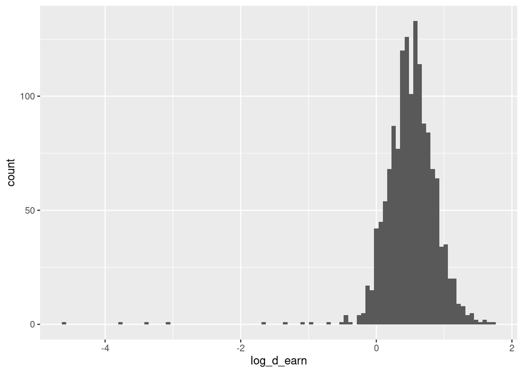

```r
# Plot the histograms for these variables
ggplot(yu_df, aes(x=log_d_earn)) +
  geom_histogram(bins = 100)
```

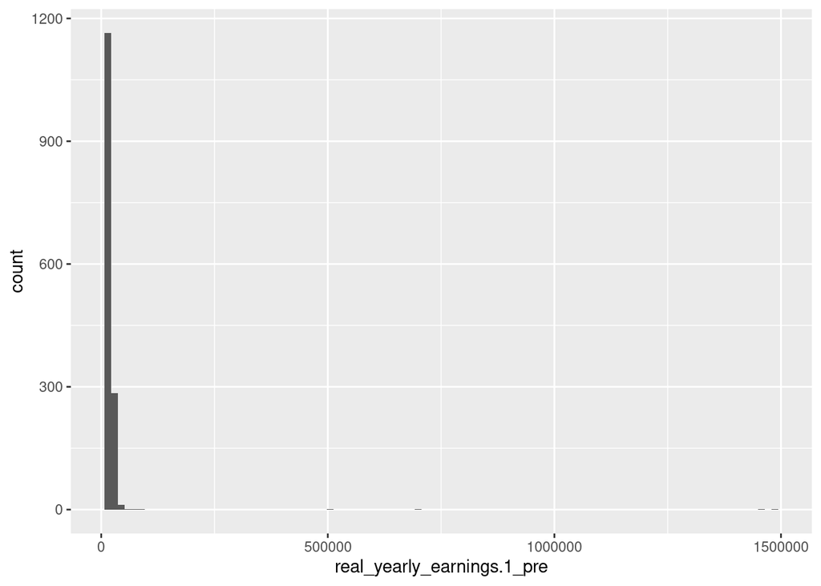

```r
ggplot(yu_df, aes(x=real_yearly_earnings.1_pre)) +
  geom_histogram(bins = 100)
```

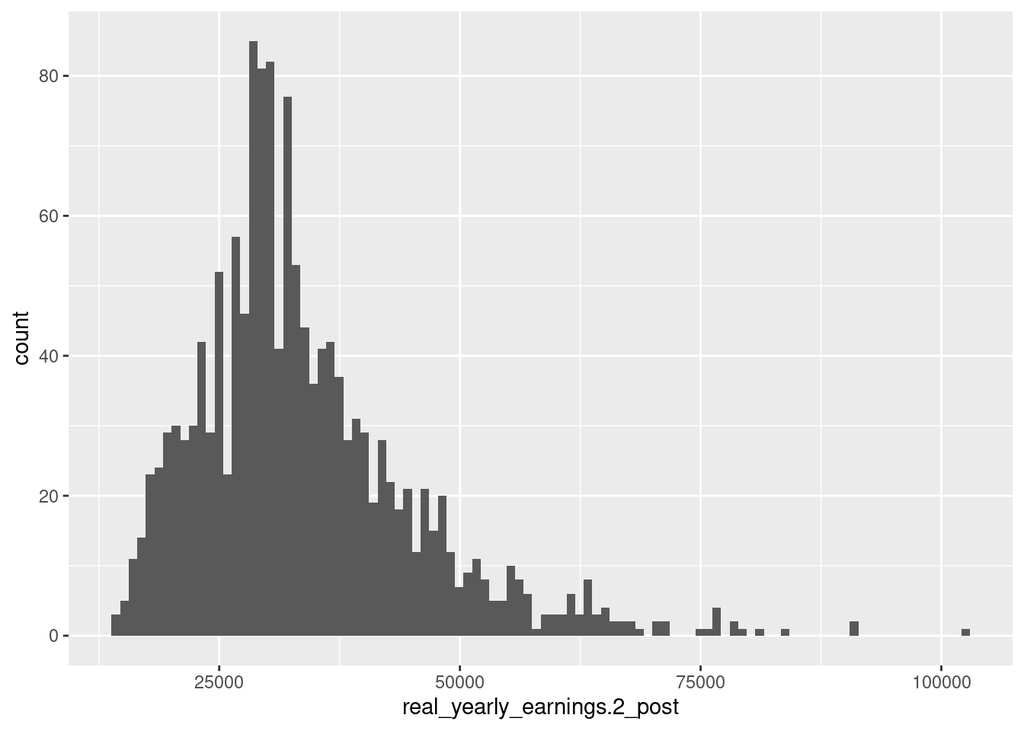

```r
ggplot(yu_df, aes(x=real_yearly_earnings.2_post)) +
  geom_histogram(bins = 100)
```

We can already see that in YU pre-wages, there are some extremely high incomes, that are likely data-entry mistakes. Nobody with incomes over one-million needs to go through the YU program!

NOTE: Feel free to add more histogram plots for other variables you think might be important to your analysis!

```r
# Get the min and max real yearly earnings for YU participants BEFORE the training program
min(yu_df$real_yearly_earnings.1_pre)
```

```
## [1] 12822.18
```

```r
max(yu_df$real_yearly_earnings.1_pre)
```

```
## [1] 1484798
```

```r
# Get the min and max real yearly earnings for YU participants AFTER the training program
min(yu_df$real_yearly_earnings.2_post)
```

```
## [1] 13877.58
```

```r
max(yu_df$real_yearly_earnings.2_post)
```

```
## [1] 102139
```

```r
high_rye <- yu_df[yu_df$real_yearly_earnings.1_pre > 150000 | yu_df$real_yearly_earnings.2_post > 150000]

# Percent change in income after YU training program
((high_rye$real_yearly_earnings.2_post - high_rye$real_yearly_earnings.1_pre) / high_rye$real_yearly_earnings.1_pre) * 100
```

```
## [1] -97.74461 -99.01596 -96.64094 -95.39008
```

```r
sum(yu_df$real_yearly_earnings.1_pre > 100000)
```

```
## [1] 4
```

```r
# Percent of observations with real yearly earnings above USD 100,000 BEFORE the training program
(sum(yu_df$real_yearly_earnings.1_pre>100000) / length(yu_df$real_yearly_earnings.1_pre)) * 100
```

```
## [1] 0.2722941
```

```r
sum(yu_df$real_yearly_earnings.1_pre>150000)
```

```
## [1] 4
```

```r
# Percent of observations with real yearly earnings above USD 150,000 BEFORE the training program
(sum(yu_df$real_yearly_earnings.1_pre>200000) / length(yu_df$real_yearly_earnings.1_pre)) * 100
```

```
## [1] 0.2722941
```

```r
sum(yu_df$real_yearly_earnings.1_pre>500000)
```

```
## [1] 3
```

```r
# Percent of observations with real yearly earnings above USD 500,000 BEFORE the training program
(sum(yu_df$real_yearly_earnings.1_pre>500000) / length(yu_df$real_yearly_earnings.1_pre)) * 100
```

```
## [1] 0.2042206
```

```r
sum(yu_df$real_yearly_earnings.1_pre>1000000)
```

```
## [1] 2
```

```r
# Percent of observations with real yearly earnings above USD 1,000,000 BEFORE the training program
(sum(yu_df$real_yearly_earnings.1_pre>1000000) / length(yu_df$real_yearly_earnings.1_pre))* 100
```

```
## [1] 0.136147
```

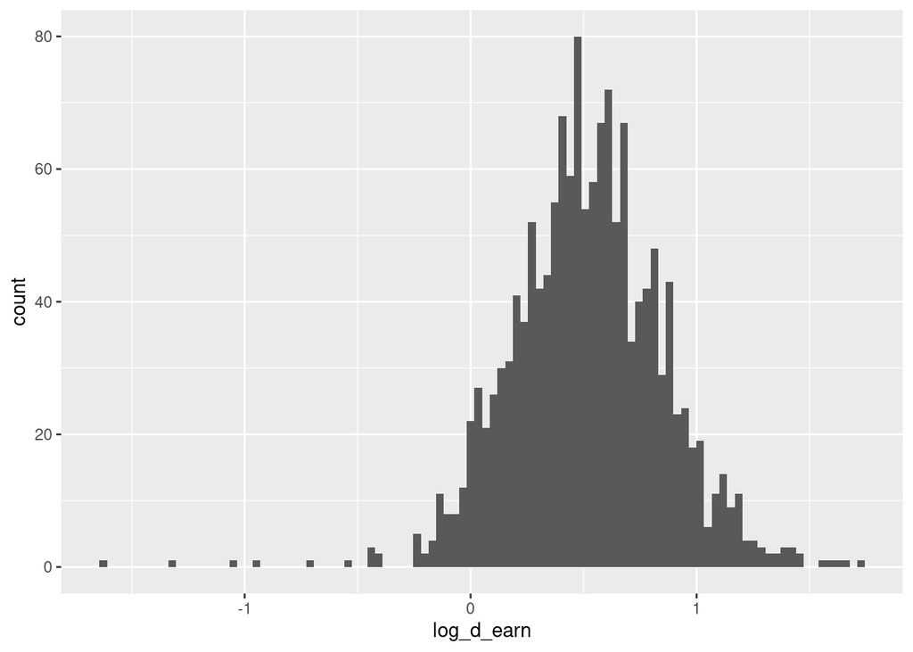

```r
# Filter out observations with real yearly earnings above USD 150,0000
yu_df = yu_df[yu_df$real_yearly_earnings.1_pre <= 150000]

# Plot the histograms for these variables
ggplot(yu_df, aes(x=log_d_earn)) +
  geom_histogram(bins = 100)
```

Observing the summary table, we notice that the maximum real yearly earning pre-YU training program is 1,484,798 which is most likely an outlier and implies that there might be other outliers. We then take a deeper dive into the data to further investigate any other potential outlier.

We then plot the histogram again and notice that the range of ‘log_d_earn’ values significantly shrunk and that the distribution is less skewed than previously when we had the outliers in the data.

## Dealing with Missing Values

```r
# Deal with missing values

# Check how many NAs there are in each variable
pct_na <- function(vec) {
  mean(is.na(vec))
}

sapply(yu_df, pct_na)
```

```
##                     PACE_ID                  log_d_earn
##                  0.00000000                  0.00000000
##         log_earnings.2_post          log_earnings.1_pre
##                  0.00000000                  0.00000000
##  real_yearly_earnings.1_pre real_yearly_earnings.2_post
##                  0.00000000                  0.00000000
##                  state_fips                        fips
##                  0.00000000                  0.00000000
##                        Site                     occ2010
##                  0.00000000                  0.04573379
##                    occ_onet                      Cohort
##                  0.00000000                  0.00000000
##                         sex                  race_white
##                  0.00000000                  0.00000000
##                  race_asian                  race_black
##                  0.00000000                  0.00000000
##                     edu_num                  experience
##                  0.00000000                  0.00000000
##                 experience2                         age
##                  0.00000000                  0.00000000
##                        age2            raw_earnings_pre
##                  0.00000000                  0.00000000
##                        year                       value
##                  0.00000000                  0.00000000
##                   occ1digit                        RTIa
##                  0.12901024                  0.12901024
##               task_abstract                 task_manual
##                  0.12901024                  0.12901024
##                task_routine                     metfips
##                  0.12901024                  0.00000000
##                  metro_name                 County_name
##                  0.00000000                  0.00000000
##                 county_fips                  state_name
##                  0.00000000                  0.00000000
##                 county_name                 cty_pop2000
##                  0.03003413                  0.03003413
##                          cz                     cz_name
##                  0.03003413                  0.03003413
##                  cz_pop2000              intersects_msa
##                  0.03003413                  0.03003413
```

[output cut: 15 more lines]

```
##                  0.03003413                  0.03003413
##             cs_born_foreign                  mig_inflow
##                  0.03003413                  0.03003413
##                 mig_outflow                 pop_density
##                  0.03003413                  0.03003413
##        frac_traveltime_lt15                     hhinc00
##                  0.03003413                  0.03003413
##          median_house_value                  cs_educ_ba
##                  0.03003413                  0.03003413
##        cs_fam_wkidsinglemom                 crime_total
##                  0.03003413                  0.11399317
##               subcty_exp_pc                     taxrate
##                  0.03003413                  0.03003413
##           tax_st_diff_top20                region_large
##                  0.03003413                  0.00000000
```

```r
yu_df  <- na.omit(yu_df ) #drop them

#summarize outcome after dropping NAs
summary(yu_df$log_d_earn)
```

```
##    Min. 1st Qu.  Median    Mean 3rd Qu.    Max.
## -1.3151  0.3032  0.5188  0.5195  0.7363  1.7126
```

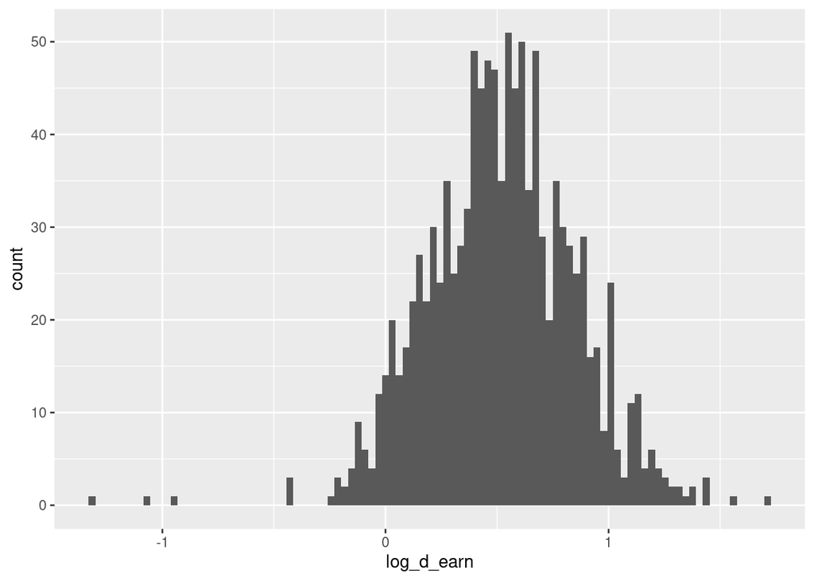

```r
# Plot the histograms for these variables
ggplot(yu_df, aes(x=log_d_earn)) +
  geom_histogram(bins = 100)
```

## Preprocessing the Dataset to Run Model Predictions on YU Data

We created a dataframe with the relevant columns for our wage prediction model and now convert certain variables, such as region_large (which represents the four regions in the US - North East, South, West and Mid-West), into categorical variables where appropriate and then convert those into dummy (or one-hot) variables. Note that with ML models, we want to avoid having too many dummy variables as certain models like random forests do not do well with them. Instead, we make sure that the variables with many categories, such as counties and occupations are instead well described using continous variables like the county neighborhood data and the task data.

Further, we again need to scale the continuous explanatory variables, the same way we did in the CPS. Indeed, we need to scale the data based on the moments of the CPS data, since we trained the model on that data and will be predicting on the YU data.

```r
yu_df<- yu_df%>% rename(log_real_yearly_earnings_1=log_earnings.1_pre)

yu_df = yu_df[, !("occ2010")] # dont need this variable

# Convert variables that are not yet into factors
class(yu_df)<-class(as.data.frame(yu_df))
categorical<-c("year", "region_large")
yu_df[ ,categorical] <- lapply(yu_df[ , categorical] , factor)
```

**NOTE: Before running the code below, please make sure you have run the initial model-building tutorial and have all the model objects saved in your project folder (i.e. the `vars.rds` object below that loads the processed CPS dataset from the initial tutorial).**

```r
# Load the CPS variables from memory
vars <- readRDS("vars.rds")
cont<- vars %>%dplyr::select(-c(year, region_large, sex, race_white,
                                race_black, race_asian)) # picking continous variables by exclduing the few categorical variables

# Select the variables from the YU data that match the ones from the CPS data
cont<-c(colnames(cont))
class(yu_df)<-class(as.data.frame(yu_df))

# Load the preprocessed CPS data from memory because we preprocess the YU data
# using the CPS training data preprocessing parameters
pre_proc_val <- readRDS("pre_proc_val.rds")
yu_df[,cont] = predict(pre_proc_val, yu_df[,cont])
```

```r
# Make dummies from all categorical variables
class(yu_df) <- class(as.data.frame(yu_df))
col_vars<-colnames(vars)
control_vars = col_vars

cols_reg = c(control_vars,  'log_d_earn')
dummies <- dummyVars(log_d_earn ~ ., data = yu_df[,cols_reg])
yu_df_dummies = predict(dummies, newdata = yu_df[,cols_reg])

# Manually create one missing category
yu_df_dummies <- as.data.frame(yu_df_dummies)
yu_df_dummies <-yu_df_dummies %>% mutate(year.2006=0)

# Make sure columns are in same order across the CPS and YU datasets
cols <- readRDS("cols.rds")
yu_df_dummies <-yu_df_dummies %>% select(cols)
```

# Using the Ridge Model to Predict Counterfactual Wage Changes in the YU Data

Finally, we can predict counterfactual wages for Year Up participants using our best model we built in the previous tutorial. As we have shown in the model building tutorial, the ridge model performed better than the other models we built and it was also well calibrated, which is why we use the ridge model trained on CPS data get the counterfactual wage change predictions.

We load the ridge model, that we saved in the previous tutorial and also remember that 0.001 was the optimal lambda that we obtained from crossfitting. We then use the ridge model and predict on the YU data as “new data”.

We summarize the predicted values.

```r
# Load the ridge regression model & optimal lambda from memory
load("ridge_reg_cps.rda")

# Use ridge optimal lambda obtained from the model building tutorial
optimal_lambda <- 0.001

# Convert the YU variables to be used as input features into matrix form
yu_df_xdummies = as.matrix(yu_df_dummies)

# Predict on new YU data
yu_log_d_earn_pred <- predict(ridge_reg_cps, s = optimal_lambda, newx = yu_df_xdummies)

#summary(yu_df$log_d_earn)
summary(yu_log_d_earn_pred)
```

```
##        1
##  Min.   :-0.88629
##  1st Qu.:-0.07183
##  Median : 0.04066
##  Mean   : 0.04312
##  3rd Qu.: 0.15198
##  Max.   : 0.57321
```

# Building an Overall Treatment Effect Model

Now that we have the actual yearly earning changes of Year Up participants as well as the counterfactual yearly earning changes (earning changes had they not participated in the training program), we can do the main step of the analysis and compare the two outcomes. To that end, we simply compare the average in actual yearly earning changes to the average in counterfactual yearly earning changes. That is exactly equivalent to regressing yearly earning changes on a treatment indicator, where the treatment indicator shows whether the outcome is the actual (treatment) or counterfactual (control) outcome.

```r
# Define the treatment group in YU data
treatment<-yu_df %>% mutate(treatment=1)

# Define the control group in YU data
control<-yu_df%>% mutate(treatment=0)
control<-control %>% select(-log_d_earn)

# Predict the difference in log yearly earnings for observations in the control group
control$log_d_earn <- predict(ridge_reg_cps, s = optimal_lambda, newx = yu_df_xdummies)

# Combine the treatment and control groups into one dataframe
both<-as.data.frame(rbind(control,treatment))

# Regress the difference in log yearly earnings on the treatment group
ate<-lm(log_d_earn~treatment, data=both)
# Summary statistics for the mean treatment effect
summary(ate)
```

```
##
## Call:
## lm(formula = log_d_earn ~ treatment, data = both)
##
## Residuals:
##      Min       1Q   Median       3Q      Max
## -1.83462 -0.14375 -0.00171  0.14811  1.19312
##
## Coefficients:
##             Estimate Std. Error t value Pr(>|t|)
## (Intercept) 0.043120   0.007706   5.596 2.46e-08 ***
## treatment   0.476382   0.010898  43.713  < 2e-16 ***
## ---
## Signif. codes:  0 '***' 0.001 '**' 0.01 '*' 0.05 '.' 0.1 ' ' 1
##
## Residual standard error: 0.2593 on 2262 degrees of freedom
## Multiple R-squared:  0.4579, Adjusted R-squared:  0.4577
## F-statistic:  1911 on 1 and 2262 DF,  p-value: < 2.2e-16
```

```r
# Get treatment effect by exponentiation of the coefficient of the treatment variable, which is in terms of log wage differences
exp(summary(ate)$coefficients[2,1])
```

```
## [1] 1.610238
```

# Estimating Heterogeneous Treatment Effects for Subgroups

Rememeber that we are ultimately interested in whether certain subgroups in Year Up participants do better than others. We run one such subgroup analysis here here as an example, and then it will be up to you to investigate other potentially interesting subgroups.

## Treatment Effects by Gender

There are two ways in which we can estimate treatment effects for different subgroups. The first version is to simply split the samples by gender and estimate their respective treatment effects. The second version is to estimate an interaction model, where we interact the treatment indicator with the gender variable.

Let’s start with the first version:

### Estimating the Treatment Effect for Male participants

```r
ate<-lm(log_d_earn~treatment, data=subset(both,sex==1))

summary(ate)
```

```
##
## Call:
## lm(formula = log_d_earn ~ treatment, data = subset(both, sex ==
##     1))
##
## Residuals:
##      Min       1Q   Median       3Q      Max
## -1.59404 -0.13110 -0.00159  0.13397  0.90715
##
## Coefficients:
##             Estimate Std. Error t value Pr(>|t|)
## (Intercept) 0.115458   0.009883   11.68   <2e-16 ***
## treatment   0.422654   0.013977   30.24   <2e-16 ***
## ---
## Signif. codes:  0 '***' 0.001 '**' 0.01 '*' 0.05 '.' 0.1 ' ' 1
##
## Residual standard error: 0.2479 on 1256 degrees of freedom
## Multiple R-squared:  0.4213, Adjusted R-squared:  0.4208
## F-statistic: 914.4 on 1 and 1256 DF,  p-value: < 2.2e-16
```

```r
exp(summary(ate)$coefficients[2,1])
```

```
## [1] 1.526006
```

So it looks like men have a treatment effect of 52% increase in earnings thanks to Year Up.

### Estimating the Treatment Effect for Female participants

```r
ate<-lm(log_d_earn~treatment, data=subset(both,sex==0))
summary(ate)
```

```
##
## Call:
## lm(formula = log_d_earn ~ treatment, data = subset(both, sex ==
##     0))
##
## Residuals:
##      Min       1Q   Median       3Q      Max
## -1.81135 -0.12217 -0.00936  0.12730  1.21639
##
## Coefficients:
##             Estimate Std. Error t value Pr(>|t|)
## (Intercept) -0.04734    0.01152   -4.11 4.27e-05 ***
## treatment    0.54357    0.01629   33.37  < 2e-16 ***
## ---
## Signif. codes:  0 '***' 0.001 '**' 0.01 '*' 0.05 '.' 0.1 ' ' 1
##
## Residual standard error: 0.2583 on 1004 degrees of freedom
## Multiple R-squared:  0.5259, Adjusted R-squared:  0.5254
## F-statistic:  1114 on 1 and 1004 DF,  p-value: < 2.2e-16
```

```r
exp(summary(ate)$coefficients[2,1])
```

```
## [1] 1.722141
```

### Estimating an Interaction Model

With such a large difference, it is likely that the difference in treatment effects for men and women is statistically significant. The way to formally test this is to compute confidence intervals (estimate +/- 1.96*standard errorr) around the treatment point-estimates from the standard errors in both regressions, and see whether the confidence intervals overlap. If they do not, then the difference is statistically significant. However, there is also a more direct way to see whether the difference is statistically significant - we can run a joint regression of the whole sample, and interact the treatment effect with gender.

Because of the way our two samples of treatment and control are designed in our case, (i.e. “treatment” and “control” are the same individuals, just with different outcomes - actual and counterfactual) those two approaches will give the same results. This is because the averages in covarariates across the two samples are the same. In the overall average treatment effect regression, this means you can add all the controls you want, and the treatment effect would not change.

If covariates were not the same on average across treatment and control groups, for the subgroup and the interaction effect results to be the same, one would have to interact all included variables with the gender variable. Here the two approaches are identical. The main advantage of the interaction model is that we can see directly whether the difference in treatment effects is statistically significant.

```r
ate<-lm(log_d_earn~treatment + sex*treatment+sex, data = both)

summary(ate)
```

```
##
## Call:
## lm(formula = log_d_earn ~ treatment + sex * treatment + sex,
##     data = both)
##
## Residuals:
##      Min       1Q   Median       3Q      Max
## -1.81135 -0.12645 -0.00546  0.13242  1.21639
##
## Coefficients:
##               Estimate Std. Error t value Pr(>|t|)
## (Intercept)   -0.04734    0.01126  -4.204 2.73e-05 ***
## treatment      0.54357    0.01593  34.132  < 2e-16 ***
## sex            0.16280    0.01511  10.776  < 2e-16 ***
## treatment:sex -0.12091    0.02136  -5.660 1.71e-08 ***
## ---
## Signif. codes:  0 '***' 0.001 '**' 0.01 '*' 0.05 '.' 0.1 ' ' 1
##
## Residual standard error: 0.2526 on 2260 degrees of freedom
## Multiple R-squared:  0.4861, Adjusted R-squared:  0.4854
## F-statistic: 712.5 on 3 and 2260 DF,  p-value: < 2.2e-16
```

```r
exp(summary(ate)$coefficients[2,1])
```

```
## [1] 1.722141
```

```r
exp(summary(ate)$coefficients[3,1])
```

```
## [1] 1.176798
```

```r
exp(summary(ate)$coefficients[4,1])
```

```
## [1] 0.8861099
```

It looks like women have a lot larger returns than men from Year Up! Why might that be and what is driving that? This is what we will try to uncover in the third tutorial.

**You should investigate whether there are other interesting heterogeneities by subgroups. Some potential groups you may wan to start with are race or location, but you can also think of other interesting subgroups!**